# R/RStudio (Part 1). Data wrangling, visualization & statistial analysis (CSB chap 9 + iris)

### 9.6.12 Themes

Once we have built a plot we like, we can change its general appearance by choosing a different theme. Themes allow you to quickly and consistently adapt your plots to printing requirements, etc. Here are some examples:

```r
# load data if not done for intermezzo
snow <- read_tsv("../data_wrangling/data/FauchaldEtAl2017/snow.csv")
```

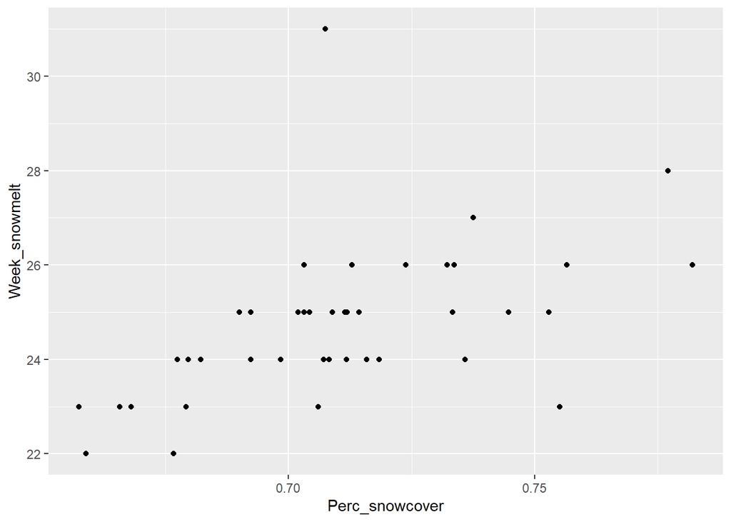

```r
pl <- ggplot(data = snow %>% filter(Herd == "CAH"), aes(y = Week_snowmelt, x = Perc_snowcover)) +
  geom_point()
# default
show(pl)
```

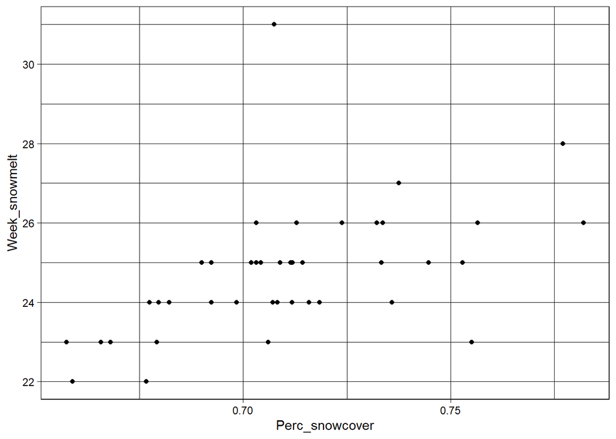

```r
# black and white (light background) pl + theme_bw()
# line draw
pl + theme_linedraw()
```

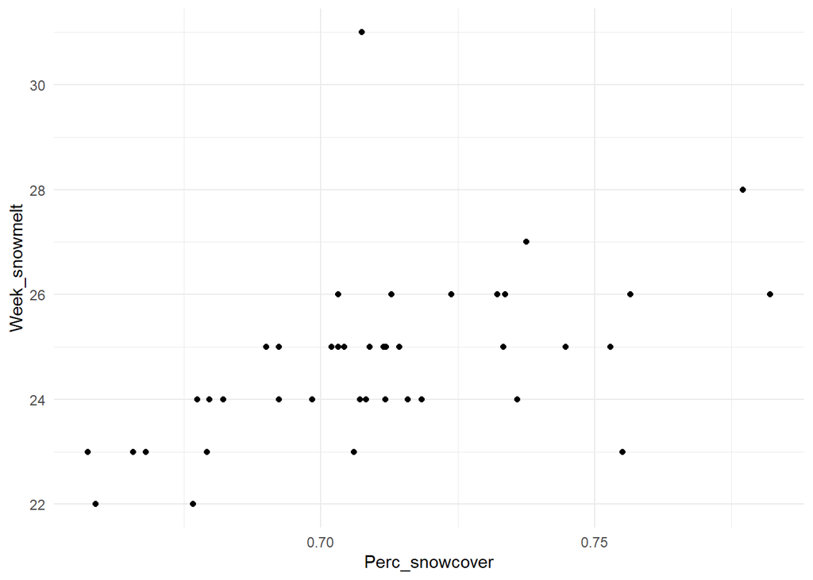

```r
# minimalist theme
pl + theme_minimal()
```

The package ggthemes provides several extra themes, including themes that mimic the style of popular publications:

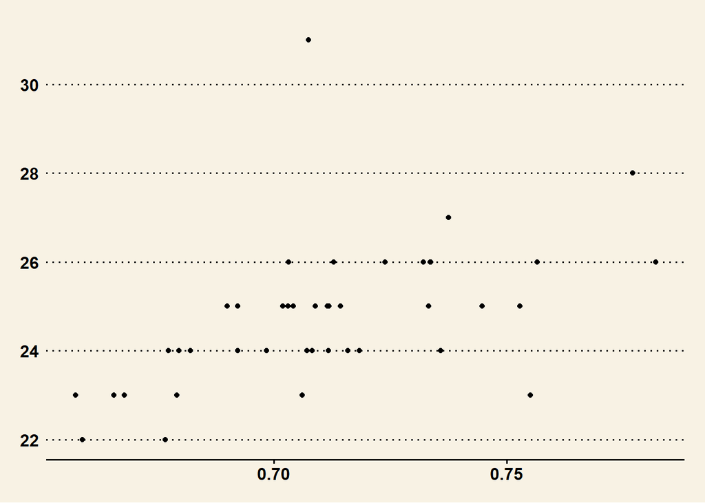

```r
#install.packages("ggthemes")
library(ggthemes)
# Wall Street Journal
show(pl + theme_wsj())
```

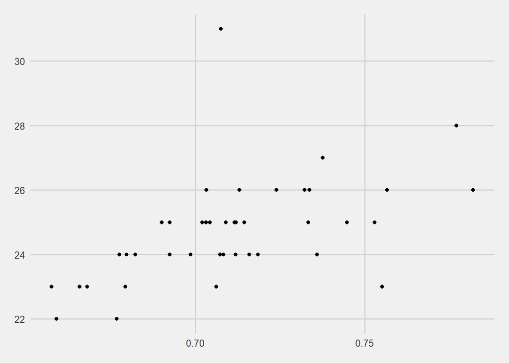

```r
# five thirty-eight
show(pl + theme_fivethirtyeight())
```

### 9.6.12 Setting a Feature

Sometimes we want to set one of the features of the graph, rather than mapping some data to it. For example, we want to have a certain size, color, shape, or transparency for all the points. To do so, we need to set the value outside the aesthetics:

```r
# use color as an aesthetic mapping, associated with Herd
pl <- ggplot(data = popsize) + aes(x = Year, y = Pop_Size, colour = Herd) + geom_point()
# set color to be red for all points
pl <- ggplot(data = popsize) + aes(x = Year, y = Pop_Size) + geom_point(colour = "red")
```

### 9.6.12 Saving

Use the function ggsave to save a plot:

```r
ggsave(filename = "../data_wrangling/sandbox/test.pdf", plot = pl, width = 3, height = 4)
```

### Intermezzo 9.6

1. For each herd (facet), produce a graph showing the histogram of the week in which ground snow melts.
2. A geometry we didn’t explore is geom_tile, which can be used to pro- duce heat maps. Explore its documentationa and draw a heat map having Year as the x-axis, Herd as the y-axis, and Week_snowmelt as the color of each cell.
3. Produce a scatter plot showing the Perc_snowcover vs. Week_ snowmelt. Facet using Herd, and add a smoothing line to each panel.

## 9.7 Tips & Tricks

If a column name is a number, or contains white spaces, you can refer to it in the code by using back ticks as quotes:

```r
popsize %>%
  filter(Year > 1979, Year < 1985) %>%
  spread(Year, Pop_Size) %>% select(Herd, `1980`)
```

```
## # A tibble: 9 x 2
##   Herd  `1980`
##   <chr>  <dbl>
## 1 BAT   140000
## 2 BEV   130000
## 3 CAH       NA
## 4 GRH   390100
## 5 LRH       NA
## 6 PCH       NA
## 7 QAM    40000
## 8 TCH       NA
## 9 WAH   138000
```

Sometimes, you need to remove the grouping information before proceeding with your pipeline. To remove all the information on groups from a tibble, pass it to ungroup.

```r
# to see the difference, run the code with # and without ungroup
popsize %>%
  group_by(Herd, Year) %>%
  tally() %>%
  ungroup() %>%
  summarise(n = sum(n))
```

```
## # A tibble: 1 x 1
##       n
##   <int>
## 1   114
```

Operations by row. We have performed operations involving columns (or subsets of columns). When you want to perform an operation by row you can use rowwise. Suppose you want to generate a new column that contains the highest values of NDVI_May and NDVI_June_August, respectively, for each year and herd. The following does not work:

```r
ndvi %>%
  mutate(maxndvi = max(NDVI_May,NDVI_June_August)) %>%
  head(4)
```

```
## # A tibble: 4 x 5
##   Herd   Year NDVI_May NDVI_June_August maxndvi
##   <chr> <dbl>    <dbl>            <dbl>   <dbl>
## 1 BAT    1982    0.214            0.372    6.31
## 2 BAT    1983    0.204           -0.998    6.31
## 3 BAT    1984    0.246            1.59     6.31
## 4 BAT    1985    0.244            0.642    6.31
```

This is because the maximum is taken over all the values in each column. In such cases, you can apply the function row by row:

```r
ndvi %>%
  rowwise() %>% mutate(maxndvi = max(NDVI_May, NDVI_June_August)) %>%
  head(4)
```

```
## # A tibble: 4 x 5
## # Rowwise:
##   Herd   Year NDVI_May NDVI_June_August maxndvi
##   <chr> <dbl>    <dbl>            <dbl>   <dbl>
## 1 BAT    1982    0.214            0.372   0.372
## 2 BAT    1983    0.204           -0.998   0.204
## 3 BAT    1984    0.246            1.59    1.59
## 4 BAT    1985    0.244            0.642   0.642
```

## Statistical analysis on the iris data set

### Step 1. Examine variable types & stats

```r
# load data
data(iris)

# show column data types
glimpse(iris)
```

```
## Rows: 150
## Columns: 5
## $ Sepal.Length <dbl> 5.1, 4.9, 4.7, 4.6, 5.0, 5.4, 4.6, 5.0, 4.4, 4.9, 5.4, 4.~
## $ Sepal.Width  <dbl> 3.5, 3.0, 3.2, 3.1, 3.6, 3.9, 3.4, 3.4, 2.9, 3.1, 3.7, 3.~
## $ Petal.Length <dbl> 1.4, 1.4, 1.3, 1.5, 1.4, 1.7, 1.4, 1.5, 1.4, 1.5, 1.5, 1.~
## $ Petal.Width  <dbl> 0.2, 0.2, 0.2, 0.2, 0.2, 0.4, 0.3, 0.2, 0.2, 0.1, 0.2, 0.~
## $ Species      <fct> setosa, setosa, setosa, setosa, setosa, setosa, setosa, s~
```

```r
# descriptive stats for each column
summary(iris)
```

```
##   Sepal.Length    Sepal.Width     Petal.Length    Petal.Width
##  Min.   :4.300   Min.   :2.000   Min.   :1.000   Min.   :0.100
##  1st Qu.:5.100   1st Qu.:2.800   1st Qu.:1.600   1st Qu.:0.300
##  Median :5.800   Median :3.000   Median :4.350   Median :1.300
##  Mean   :5.843   Mean   :3.057   Mean   :3.758   Mean   :1.199
##  3rd Qu.:6.400   3rd Qu.:3.300   3rd Qu.:5.100   3rd Qu.:1.800
##  Max.   :7.900   Max.   :4.400   Max.   :6.900   Max.   :2.500
##        Species
##  setosa    :50
##  versicolor:50
##  virginica :50
##
##
##
```

### Step 2. Show data distributions

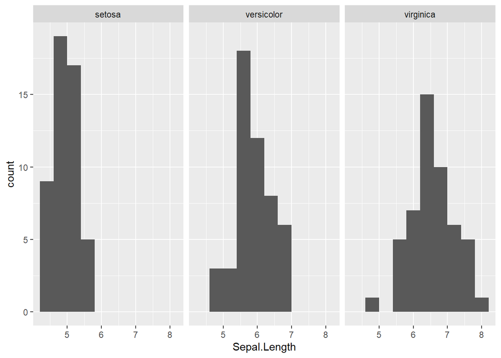

```r
# histograms:
# distribute (ie. frequency, on y-axis) of a numerical variable (on x-axis)
# shows the data range and mode of a nuemerical variable
# test data normality (log transform if not)
iris %>%
  ggplot(aes(x=Sepal.Length)) +
  geom_histogram(bins=10) +
  facet_wrap(~Species)
```

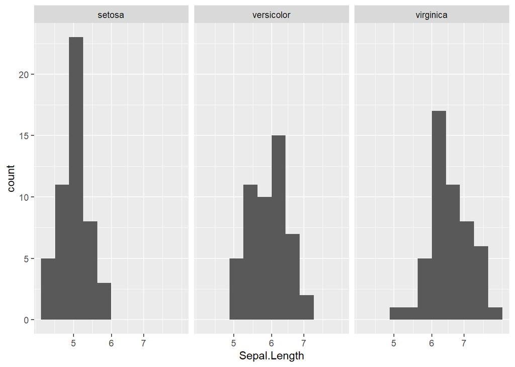

```r
# apply log transformation
iris %>%
  ggplot(aes(x=Sepal.Length)) +
  geom_histogram(bins=10) +
  facet_wrap(~Species) +
  scale_x_log10()
```

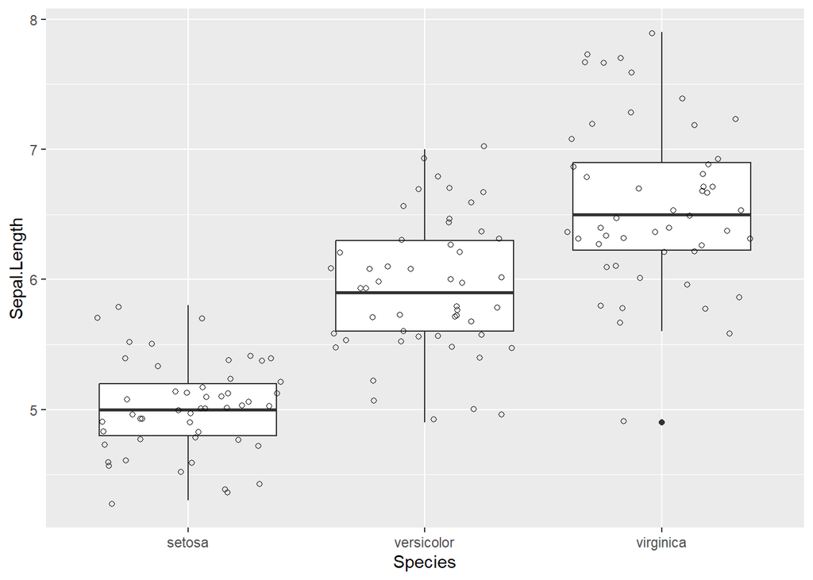

```r
# boxplot:
# categorical variable on x-axis
# numerical variable on y-axis
# show medians and ranges by a catagory
# better than barplot
# add jittered points to show sample sizes
iris %>%
  ggplot(aes(x=Species, y = Sepal.Length)) +
  geom_boxplot() +
  geom_jitter(shape = 1)
```

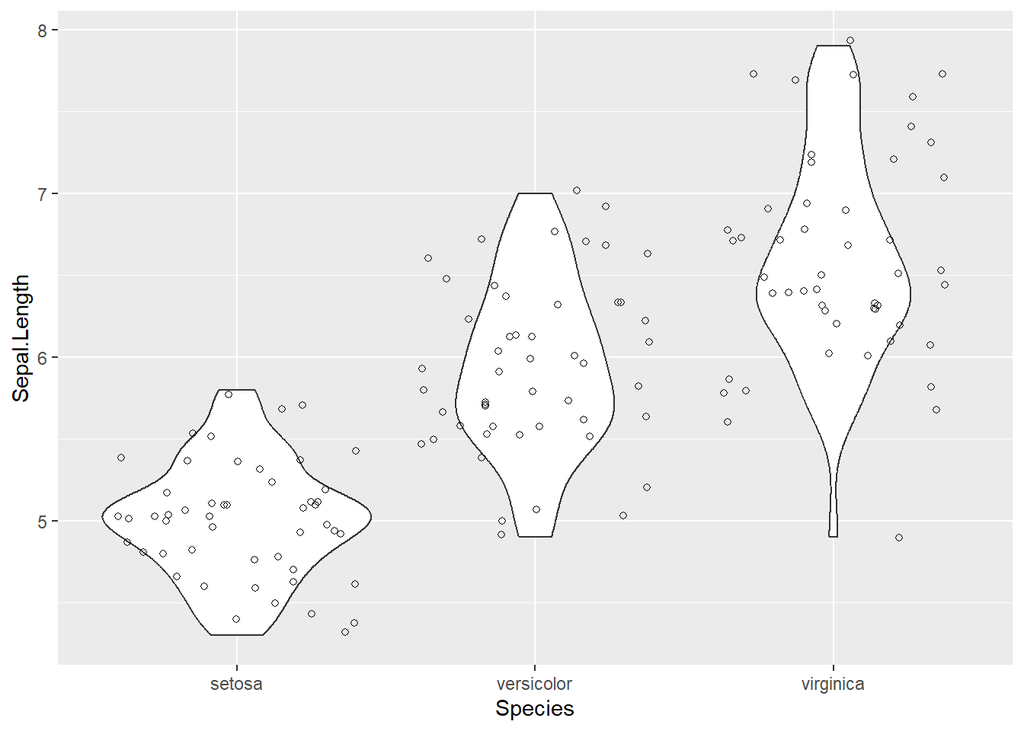

```r
# violin plot (an alternative to boxplot)
# side-way histogram or density curve, width corresponding to frequency
iris %>%
  ggplot(aes(x=Species, y = Sepal.Length)) +
  geom_violin() +
  geom_jitter(shape = 1)
```

### Stat 1. t-test: difference of a numerical variable between two categories

```r
# Biological hypothesis: sepal length differs between Setosa and Virginica
# Numerical variable: Sepal.Length
# two categories: Setosa and Virginica
# Statistical null hypothesis: no difference in means (u1 = u2)
iris %>%
  filter(Species != 'versicolor') %>%
  t.test(data = ., Sepal.Length ~ Species)
```

```
##
##  Welch Two Sample t-test
##
## data:  Sepal.Length by Species
## t = -15.386, df = 76.516, p-value < 2.2e-16
## alternative hypothesis: true difference in means between group setosa and group virginica is not equal to 0
## 95 percent confidence interval:
##  -1.78676 -1.37724
## sample estimates:
##    mean in group setosa mean in group virginica
##                   5.006                   6.588
```

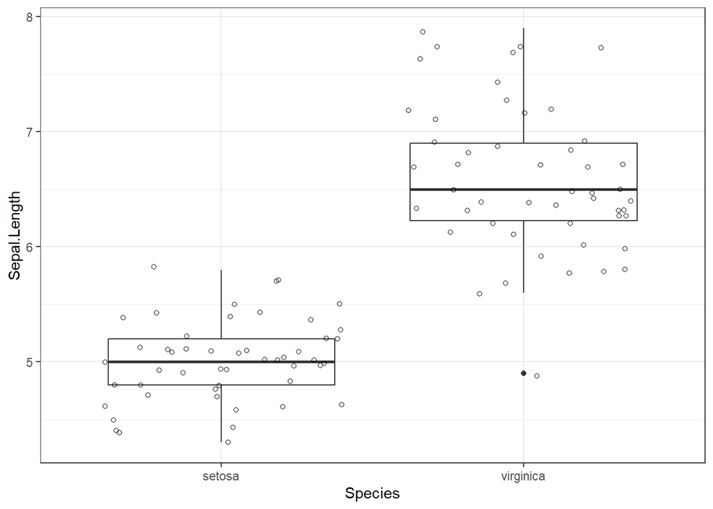

```r
# Statistical conclusion: given the data, the two means are the same by chance at a probability of p<2.2e-16. Therefore, the null hypothesis is rejected
# Biological conclusion: sepal length differ significantly between the two species

# visualization
# with a boxplot & jittered data points
iris %>%
  filter(Species != 'versicolor') %>%
  ggplot(aes(x = Species, y = Sepal.Length)) +
  geom_boxplot() +
  geom_jitter(shape = 1) +
  theme_bw()
```

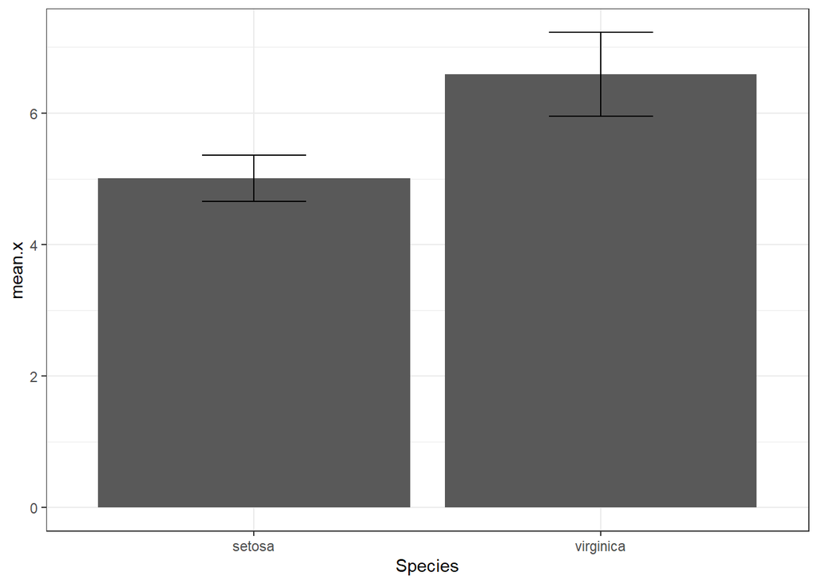

```r
# bar graph
iris %>%
  filter(Species != 'versicolor') %>%
  group_by(Species) %>%
  summarise(mean.x = mean(Sepal.Length), sd.x = sd(Sepal.Length)) %>%
  ggplot(aes(x = Species, y = mean.x, ymin = mean.x - sd.x, ymax = mean.x + sd.x)) +
  geom_col() +
  geom_errorbar(width = .3) +
  theme_bw()
```